# Homework 10

Use the RLT package for Questions 1 and 2: `RLT` in R or `rlt` in Python. The node-size parameter is `nmin` in R and `min_samples_leaf` in Python; both stop splitting a node when it contains at most that many observations. The candidate-predictor parameter is `mtry` in both languages. Use ordinary random forests, with reinforcement turned off.

## Question 1: Bias-variance trade-off simulation

Two important tuning parameters of random forests are node size and `mtry`. We have performed some preliminary analysis in class. The goal of this question is to perform a larger simulation study for these two tuning parameters.

Consider a regression model with five jointly normally distributed predictors. Each predictor has mean 0 and variance 1, and the correlation between any two different predictors is 0.3. The response is

$$Y=X_1+X_3+X_5+\varepsilon,
\qquad \varepsilon\sim N(0,1),$$

where the noise is independent of the predictors. Thus the true regression function is $f(\mathbf{x})=x_1+x_3+x_5$.

1. Set up a simulation study with 100 repetitions. Generate 200 test predictor vectors once and keep them fixed. In each repetition, generate 200 new training observations and use the same training data for all tuning settings. Fit 500-tree forests, drawing 200 observations with replacement for each tree. Make the following two comparisons:
   - Fix `mtry` at 3 and vary node size over $1,5,10,20,30$.
   - Fix node size at 10 and vary `mtry` over $1,2,3,4,5$.

   Leave all other fitting parameters at their defaults. Record the predictions at each test point across repetitions. For each setting, estimate the squared bias and variance at each test point, then average them over the 200 test points. Compare predictions with $f(\mathbf{x})$ when estimating bias. Produce two figures, one for each tuning parameter, showing the averaged squared bias and variance. Set a random seed and report it.
2. Discuss your results in terms of the bias-variance trade-off:
   - How does a large node size, such as 30, affect the fit in this example?
   - What are the benefits and drawbacks of using a large `mtry` value?
   - If each tree instead sampled 100 observations with replacement, would you expect the preferred node size to shift toward smaller or larger values? Explain your reasoning. You may use an additional simulation to help, but a particular pattern is not guaranteed.

## Question 2: Tuning random forests for MNIST

Use `mnist-first2000.csv.gz` from the combined ZIP. It contains 2,000 MNIST observations, with the digit label `Digit` and 784 pixel values.

- From the first 1,000 observations, keep digits 1, 6, and 7 as the training data. From the remaining 1,000 observations, keep the same digits as the test data.
- Fit PCA to the training pixels, centering but not scaling them. Use the first 20 principal components as predictors, and project the test observations using the same training means and loadings.

Complete the following tasks using RLT classification forests with 1,000 trees. For each tree, draw a bootstrap sample of the same size as the training set.

1. Fit a random forest with the default `mtry` and node-size settings. Report the out-of-bag (OOB) misclassification rate.
2. Construct a grid of `mtry` and node-size values to tune the model. Select the setting using OOB misclassification rate. Report the OOB error for each setting and the selected values. Calculate and present the selected forest’s OOB permutation variable importance for the 20 principal components. Comment on your results.
3. Apply the selected model to the test data and report the misclassification rate and confusion matrix. Use the test labels only for this final assessment.

## Question 3: Planning a random-forest analysis skill

In earlier homework, some students wrote long skill files with detailed instructions, while others wrote short skills emphasizing their specific requirements or references. These approaches may perform differently depending on the AI and the task. A capable AI may already know standard ways to perform an analysis, so some instructions may be redundant, add little value, or sometimes make the analysis worse. It may be more useful to specify your personal choices for the analysis. An AI with more limited knowledge may benefit from detailed instructions that remind it of the steps to perform.

1. Write one paragraph describing how you would write a skill that directs an AI to perform a random-forest analysis and produce a report for a future dataset. Discuss how you would balance standard analysis instructions with your personal preferences, considering the AI’s capabilities.
2. Provide **10 instructions** you would consider including in the skill, **ordered from the most basic instructions to the more personal preferences**. Your list may cover computation, tuning, tables, figures, interpretation, presentation, or other aspects of a random-forest report.

You only need to discuss how the skill should be written. You are not required to write a complete skill file or test it.

# Solutions

## Question 1

### (a) Simulation

I use random seed **20261101**. For a fixed test point $x$, the estimated squared bias is $(\overline{\hat f(x)}-f(x))^2$, and the estimated variance is $\frac{1}{99}\sum_{r=1}^{100}(\hat f_r(x)-\overline{\hat f(x)})^2$. The reported quantities average these estimates over all 200 fixed test points.

```r
library(RLT)
library(ggplot2)
library(knitr)
set.seed(20261101)

Sigma <- matrix(0.3, 5, 5)
diag(Sigma) <- 1
make_x <- function(n) {
  matrix(rnorm(n * 5), n, 5) %*% chol(Sigma)
}
f_true <- function(x) rowSums(x[, c(1, 3, 5), drop = FALSE])
X_test <- make_x(200)
truth <- f_true(X_test)
node_grid <- c(1L, 5L, 10L, 20L, 30L)
mtry_grid <- 1:5
settings <- unique(rbind(
  data.frame(comparison = "Node size", nmin = node_grid, mtry = 3L),
  data.frame(comparison = "mtry", nmin = 10L, mtry = mtry_grid)
))
# Each (nmin, mtry) pair is fitted only once per repetition.
settings <- unique(settings[c("nmin", "mtry")])
predictions <- array(NA_real_, c(100, nrow(X_test), nrow(settings)))

for (r in seq_len(100)) {
  X_train <- make_x(200)
  Y_train <- f_true(X_train) + rnorm(200)
  for (j in seq_len(nrow(settings))) {
    fit <- RLT::RLT(
      X_train, Y_train, model = "regression", ntrees = 500,
      nmin = settings$nmin[j], mtry = settings$mtry[j],
      resample.prob = 1, reinforcement = FALSE
    )
    predictions[r, , j] <- as.numeric(predict(fit, X_test)$Prediction)
  }
}
```

[output not shown]

[output cut: 845 more lines]

[output not shown]

```r
results1 <- do.call(rbind, lapply(seq_len(nrow(settings)), function(j) {
  mat <- predictions[, , j]
  mu <- colMeans(mat)
  data.frame(nmin = settings$nmin[j], mtry = settings$mtry[j],
             squared_bias = mean((mu - truth)^2),
             variance = mean(apply(mat, 2, var)))
}))
kable(results1, digits = 4, caption = "Average squared bias and variance")
```

Average squared bias and variance

| nmin | mtry | squared_bias | variance |
| --- | --- | --- | --- |
| 1 | 3 | 0.2159 | 0.1084 |
| 5 | 3 | 0.2090 | 0.0971 |
| 10 | 3 | 0.2208 | 0.0798 |
| 20 | 3 | 0.2811 | 0.0632 |
| 30 | 3 | 0.3639 | 0.0569 |
| 10 | 1 | 0.6341 | 0.0416 |
| 10 | 2 | 0.2969 | 0.0615 |
| 10 | 4 | 0.1930 | 0.0978 |
| 10 | 5 | 0.1803 | 0.1099 |

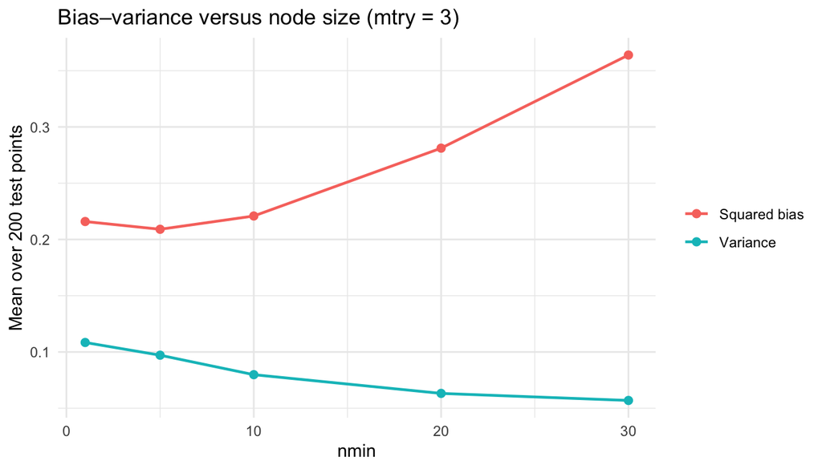

```r
plot_tradeoff <- function(d, parameter, heading) {
  long <- rbind(
    data.frame(value = d[[parameter]], metric = "Squared bias", estimate = d$squared_bias),
    data.frame(value = d[[parameter]], metric = "Variance", estimate = d$variance)
  )
  ggplot(long, aes(value, estimate, color = metric)) +
    geom_line(linewidth = 0.8) + geom_point(size = 2) +
    labs(title = heading, x = parameter, y = "Mean over 200 test points", color = NULL) +
    theme_minimal()
}
plot_tradeoff(subset(results1, mtry == 3), "nmin", "Bias–variance versus node size (mtry = 3)")
```

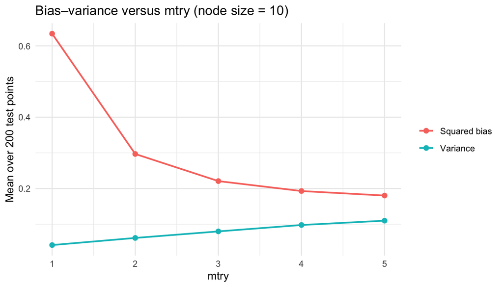

```r
plot_tradeoff(subset(results1, nmin == 10), "mtry", "Bias–variance versus mtry (node size = 10)")
```

### (b) Discussion

A large node size such as 30 prevents the trees from making many fine splits. This produces smoother predictions and typically lowers variance, but it can increase squared bias because the trees cannot fully adapt to the regression function. In this example the true signal is linear and additive, so overly coarse leaves can still lose important information about the three relevant predictors.

A large `mtry` makes it more likely that a relevant predictor is available at each split. This can reduce bias and strengthen individual trees, especially because only three of the five predictors enter the response. However, trees become more similar to one another when they repeatedly select the same strong variables, reducing the variance-reduction benefit of averaging. The best value therefore depends on the balance between individual-tree accuracy and correlation among trees; it should be assessed using the figure rather than assumed in advance.

If each tree instead drew only 100 bootstrap observations, I would generally expect the preferred node size to shift **smaller**. Each tree would see fewer distinct observations, so a node size of 30 would stop splitting particularly early and could lead to substantial underfitting. Smaller nodes could recover some flexibility, although they may also increase variance. This is an expectation, not a guaranteed simulation result.

## Question 2

The following code uses only the **training** subset to fit PCA and select tuning parameters. The test labels are used only in the final evaluation.

```r
library(RLT)
library(knitr)
set.seed(20261101)
mnist <- read.csv("data/mnist-first2000.csv.gz")
stopifnot(nrow(mnist) == 2000, "Digit" %in% names(mnist))
train_raw <- mnist[1:1000, , drop = FALSE]
test_raw <- mnist[1001:2000, , drop = FALSE]
train_raw <- train_raw[train_raw$Digit %in% c(1, 6, 7), , drop = FALSE]
test_raw <- test_raw[test_raw$Digit %in% c(1, 6, 7), , drop = FALSE]
pixel_cols <- setdiff(names(mnist), "Digit")
train_pixels <- as.matrix(train_raw[, pixel_cols])
test_pixels <- as.matrix(test_raw[, pixel_cols])
pca <- prcomp(train_pixels, center = TRUE, scale. = FALSE, rank. = 20)
X_train <- pca$x[, 1:20, drop = FALSE]
X_test <- scale(test_pixels, center = pca$center, scale = FALSE) %*%
  pca$rotation[, 1:20, drop = FALSE]
y_train <- as.factor(train_raw$Digit)
y_test <- factor(test_raw$Digit, levels = levels(y_train))
cat("Training size:", nrow(X_train), "; test size:", nrow(X_test), "\n")
```

```
Training size: 327 ; test size: 317
```

### (a) Default forest

```r
# RLT's OOB misclassification is available from the fitted object's OOB predictions.
get_pred <- function(object, newx = NULL) {
  ans <- if (is.null(newx)) object else predict(object, newx)
  for (name in c("ProbPrediction", "Prediction", "prediction", "pred", "OOBPrediction", "OOBprediction")) {
    if (!is.null(ans[[name]])) return(ans[[name]])
  }
  stop("Cannot locate predictions: inspect names(fit) and names(predict(fit, X_train)).")
}
classes <- levels(y_train)
as_labels <- function(x) {
  if (is.matrix(x)) {
    if (ncol(x) == length(classes)) return(classes[max.col(x, ties.method = "first")])
    x <- as.vector(x)
  }
  if (is.numeric(x) && all(is.na(x) | x %in% seq_along(classes)))
    return(classes[as.integer(x)])
  as.character(x)
}
get_oob <- function(fit) {
  for (name in c("OOBPrediction", "OOBprediction", "oob.prediction", "oob_pred")) {
    if (!is.null(fit[[name]])) return(as_labels(fit[[name]]))
  }
  # RLT 3.2.6 exposes per-tree probabilities and bootstrap counts.
  if (!is.null(fit$ObsTrack)) {
    per_tree <- predict(fit, X_train)$AllPrediction
    oob <- fit$ObsTrack == 0
    counts <- rowSums(oob)
    stopifnot(all(counts > 0), length(per_tree) == ncol(oob))
    probabilities <- matrix(0, nrow(X_train), length(classes))
    for (tree in seq_along(per_tree)) {
      probabilities <- probabilities + per_tree[[tree]] * oob[, tree]
    }
    return(as_labels(probabilities / counts))
  }
  stop("OOB predictions unavailable: enable bootstrap observation tracking.")
}
fit_forest <- function(mtry = NULL, nmin = NULL, importance = FALSE) {
  args <- list(X_train, y_train, model = "classification", ntrees = 1000,
               resample.prob = 1, reinforcement = FALSE, importance = importance,
               track.obs = TRUE)
  if (!is.null(mtry)) args$mtry <- mtry
  if (!is.null(nmin)) args$nmin <- nmin
  do.call(RLT::RLT, args)
}
fit_default <- fit_forest()
```

```
Package is not compiled with OpenMP (omp.h).
```

```r
default_oob <- get_oob(fit_default)
cat("Default OOB misclassification rate:", mean(default_oob != as.character(y_train), na.rm = TRUE), "\n")
```

```
Default OOB misclassification rate: 0.03058104
```

### (b) OOB tuning and permutation importance

I compare `mtry` values 2, 4, 6, 10, and 20 and node sizes 1, 5, 10, and 20. I select the model with the smallest OOB misclassification rate, breaking ties by smaller `mtry` and then smaller node size.

```r
params <- expand.grid(mtry = c(2L, 4L, 6L, 10L, 20L),
                      nmin = c(1L, 5L, 10L, 20L))
params$oob_error <- NA_real_
for (j in seq_len(nrow(params))) {
  model <- fit_forest(params$mtry[j], params$nmin[j])
  params$oob_error[j] <- mean(get_oob(model) != as.character(y_train), na.rm = TRUE)
}
```

[output not shown]

```r
params <- params[order(params$oob_error, params$mtry, params$nmin), ]
kable(params, digits = 4, caption = "Grid search: OOB misclassification rates")
```

Grid search: OOB misclassification rates

|  | mtry | nmin | oob_error |
| --- | --- | --- | --- |
| 1 | 2 | 1 | 0.0183 |
| 7 | 4 | 5 | 0.0183 |
| 11 | 2 | 10 | 0.0245 |
| 16 | 2 | 20 | 0.0245 |
| 8 | 6 | 5 | 0.0245 |
| 6 | 2 | 5 | 0.0275 |
| 2 | 4 | 1 | 0.0275 |
| 12 | 4 | 10 | 0.0275 |
| 9 | 10 | 5 | 0.0306 |
| 5 | 20 | 1 | 0.0306 |
| 10 | 20 | 5 | 0.0306 |
| 17 | 4 | 20 | 0.0336 |
| 3 | 6 | 1 | 0.0336 |
| 13 | 6 | 10 | 0.0336 |
| 4 | 10 | 1 | 0.0336 |
| 15 | 20 | 10 | 0.0367 |
| 14 | 10 | 10 | 0.0398 |
| 19 | 10 | 20 | 0.0398 |
| 18 | 6 | 20 | 0.0428 |
| 20 | 20 | 20 | 0.0428 |

```r
best <- params[1, ]
cat("Selected mtry:", best$mtry, "; selected nmin:", best$nmin,
    "; selected OOB error:", best$oob_error, "\n")
```

```
Selected mtry: 2 ; selected nmin: 1 ; selected OOB error: 0.01834862
```

```r
selected <- fit_forest(best$mtry, best$nmin, importance = TRUE)
```

```
Package is not compiled with OpenMP (omp.h).
```

```r
# RLT versions may use different field names for permutation importance.
importance_values <- NULL
for (field in c("VarImp", "varimp", "importance", "Importance", "variable.importance")) {
  if (!is.null(selected[[field]])) {
    importance_values <- selected[[field]]
    break
  }
}
if (is.null(importance_values)) {
  cat("Importance field not detected. Inspect names(selected) for your installed RLT version.\n")
} else {
  importance_values <- as.numeric(importance_values)
  if (length(importance_values) == 20) {
    imp <- data.frame(PC = paste0("PC", 1:20), importance = importance_values)
    imp <- imp[order(-imp$importance), ]
    kable(imp, digits = 4, caption = "OOB permutation importance of principal components")
  } else {
    print(importance_values)
  }
}
```

OOB permutation importance of principal components

|  | PC | importance |
| --- | --- | --- |
| 2 | PC2 | 0.4473 |
| 1 | PC1 | 0.3400 |
| 5 | PC5 | 0.1013 |
| 3 | PC3 | 0.0985 |
| 6 | PC6 | 0.0924 |
| 7 | PC7 | 0.0720 |
| 4 | PC4 | 0.0682 |
| 11 | PC11 | 0.0619 |
| 12 | PC12 | 0.0526 |
| 18 | PC18 | 0.0512 |
| 10 | PC10 | 0.0510 |
| 14 | PC14 | 0.0475 |
| 13 | PC13 | 0.0427 |
| 8 | PC8 | 0.0401 |
| 16 | PC16 | 0.0386 |
| 9 | PC9 | 0.0373 |
| 17 | PC17 | 0.0351 |
| 20 | PC20 | 0.0336 |
| 15 | PC15 | 0.0308 |
| 19 | PC19 | 0.0277 |

Principal components with higher permutation importance contribute more to distinguishing digits 1, 6, and 7 in the selected forest. Because PCA orders components by overall pixel variance rather than predictive usefulness, PC1 need not be the most important classifier feature. The OOB errors indicate whether increasing tree complexity or considering more PCs per split improves generalization on this training subset; the test set is not involved in this decision.

### (c) Final test evaluation

```r
pred_test <- as_labels(get_pred(selected, X_test))
test_error <- mean(pred_test != as.character(y_test))
cat("Final test misclassification rate:", test_error, "\n")
```

```
Final test misclassification rate: 0.0126183
```

```r
confusion <- table(Actual = y_test,
                   Predicted = factor(pred_test, levels = classes))
kable(as.data.frame.matrix(confusion), caption = "Final test confusion matrix")
```

Final test confusion matrix

|  | 1 | 6 | 7 |
| --- | --- | --- | --- |
| 1 | 102 | 0 | 2 |
| 6 | 0 | 106 | 0 |
| 7 | 0 | 2 | 105 |

The confusion matrix identifies which digit pairs are most often confused. The test error provides an independent assessment of the model chosen using OOB error; the two rates may differ due to sampling variation.

## Question 3

### (a) Skill design

I would write a random-forest analysis skill that gives the AI a clear objective, a few nonnegotiable methodological rules, and my preferences for reporting, rather than spelling out every routine command. A capable AI should already know how to preprocess data, fit forests, and calculate standard metrics, so repeating all those steps could make the skill unnecessarily long and less flexible. However, I would explicitly require the AI to avoid data leakage, choose tuning parameters using only training data, and reserve the test set for final evaluation. I would also specify how I want the results presented: reproducible code, concise tables, readable plots, and explanations that connect tuning choices to model behavior. If the AI were less capable, I would add more detailed instructions and examples for fitting and evaluation. The goal is to make the skill specific enough to ensure reliable, consistent work without preventing the AI from adapting to a new dataset.

### (b) Ten instructions, from basic to personal

1. Identify the response variable, predictor variables, and whether the task is regression or classification.
2. Inspect data types, missing values, sample sizes, and the response distribution before fitting models.
3. Separate training and test data, and fit any preprocessing steps using training data only.
4. Set and report a random seed so the analysis can be reproduced.
5. Fit an appropriate baseline random forest and report a suitable performance metric.
6. Tune `mtry` and node size using OOB error or training-only cross-validation; never tune on the test set.
7. Report the full tuning grid and clearly identify the selected model and selection criterion.
8. Show variable importance and interpret it cautiously, especially for correlated predictors.
9. Use simple, labeled figures and compact tables; explain meaningful patterns rather than just repeating numbers.
10. End with a short interpretation of predictive performance, limitations, and the practical implications of the chosen model, using clear language rather than unnecessary jargon.